## Introduction: This R Markdown file is a Seurat tutorial that demonstrates the different steps of the analysis pipeline, including data preprocessing, quality control, normalization, dimensionality reduction, clustering, and identification of marker genes. It also covers additional analyses such as differential gene expression and cell type annotation.

# Importing Libraries

```r
library(dplyr)
library(Seurat)
library(patchwork)
```

# Opening the file

```r
pbmc.data <- Read10X(data.dir = "C:/Users/bbara/Desktop/filtered_feature_bc_matrix")
```

```r
pbmc <- CreateSeuratObject(counts = pbmc.data, project = "Nuclear RNA", min.cells=3)
dim(pbmc.data)
```

```
## [1] 33538  2700
```

```r
dim(pbmc)
```

```
## [1] 16811  2700
```

# Print the total number of cells

```r
n.cells <- ncol(pbmc@assays$RNA@counts)
print(paste0("Number of cells before filtering: ", n.cells))
```

```
## [1] "Number of cells before filtering: 2700"
```

# Filter out low-quality cells

```r
pbmc <- subset(pbmc, nFeature_RNA > 200)
pbmc
```

```
## An object of class Seurat
## 16811 features across 2689 samples within 1 assay
## Active assay: RNA (16811 features, 0 variable features)
```

# Find the percentage of mitochondrial genes

```r
pbmc[["percent.mt"]] <- PercentageFeatureSet(pbmc, pattern = "^MT-")
```

# Visualizing as Violin plot

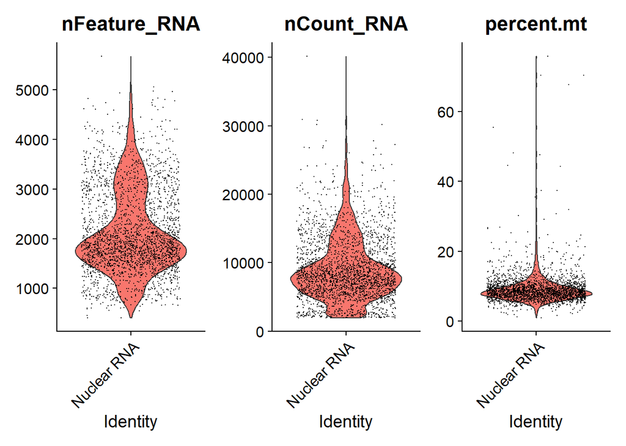

```r
VlnPlot(pbmc, features = c("nFeature_RNA", "nCount_RNA", "percent.mt"), ncol = 3)
```

# Calculating percentage of different genes

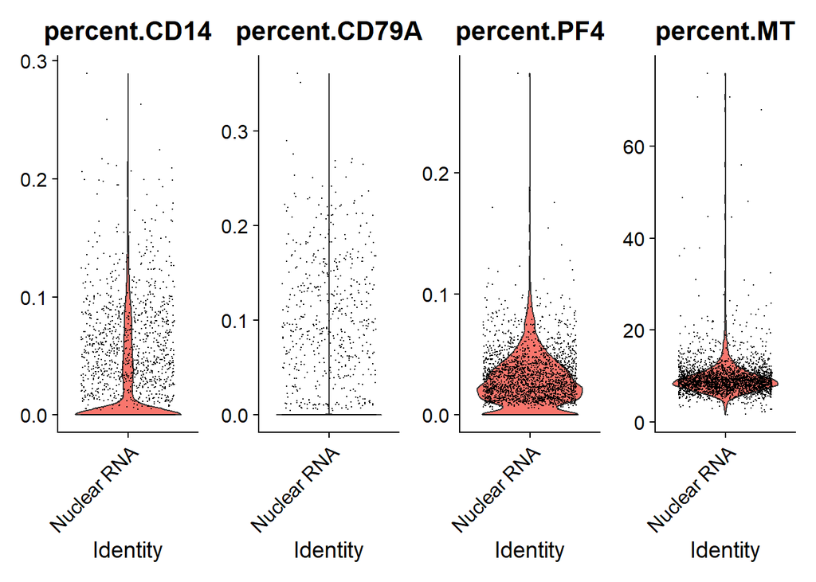

```r
gene_names <- c("CD14", "CD79A", "PF4", "MT")

# Compute the percentage of UMIs for each gene
for (gene_name in gene_names) {
  pbmc[[paste0("percent.", gene_name)]] <- PercentageFeatureSet(pbmc, pattern = paste0( gene_name))
}

# Visualize the percentage of UMIs for each gene using violin plots
VlnPlot(pbmc, features = paste0("percent.", gene_names), ncol = length(gene_names))
```

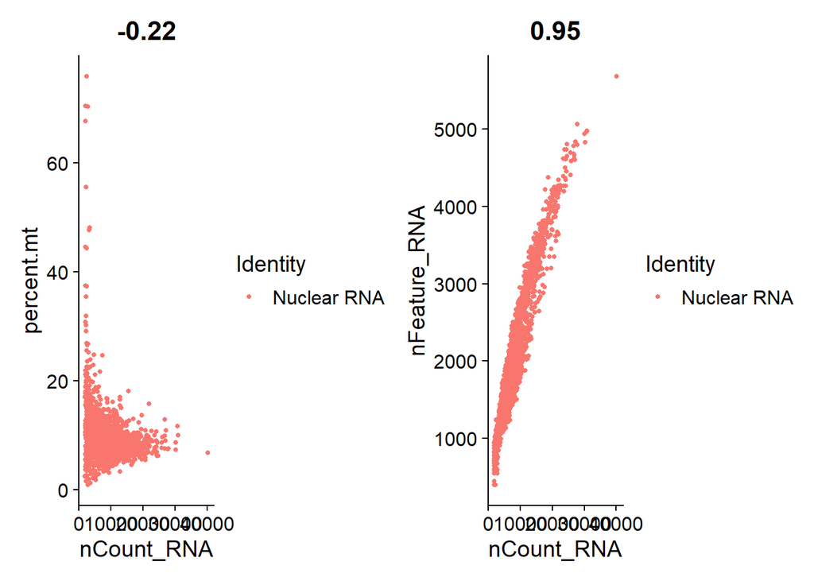

```r
plot1 <- FeatureScatter(pbmc, feature1 = "nCount_RNA", feature2 = "percent.mt")
plot2 <- FeatureScatter(pbmc, feature1 = "nCount_RNA", feature2 = "nFeature_RNA")
plot1 + plot2
```

# Visualizing as scatter plot

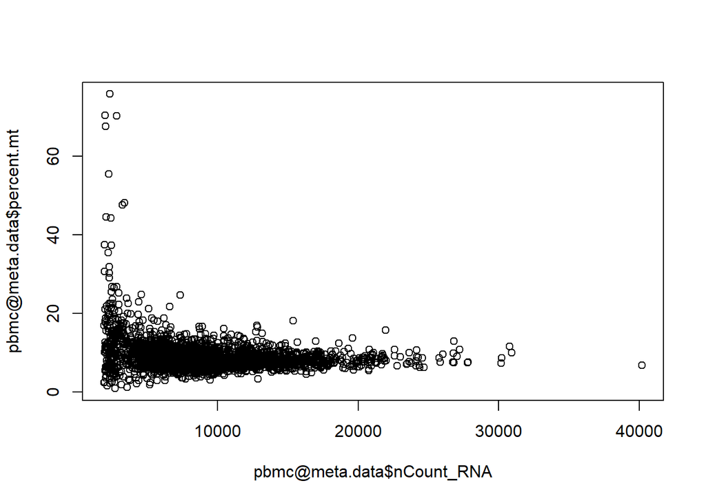

```r
plot(pbmc@meta.data$nCount_RNA, pbmc@meta.data$percent.mt)
```

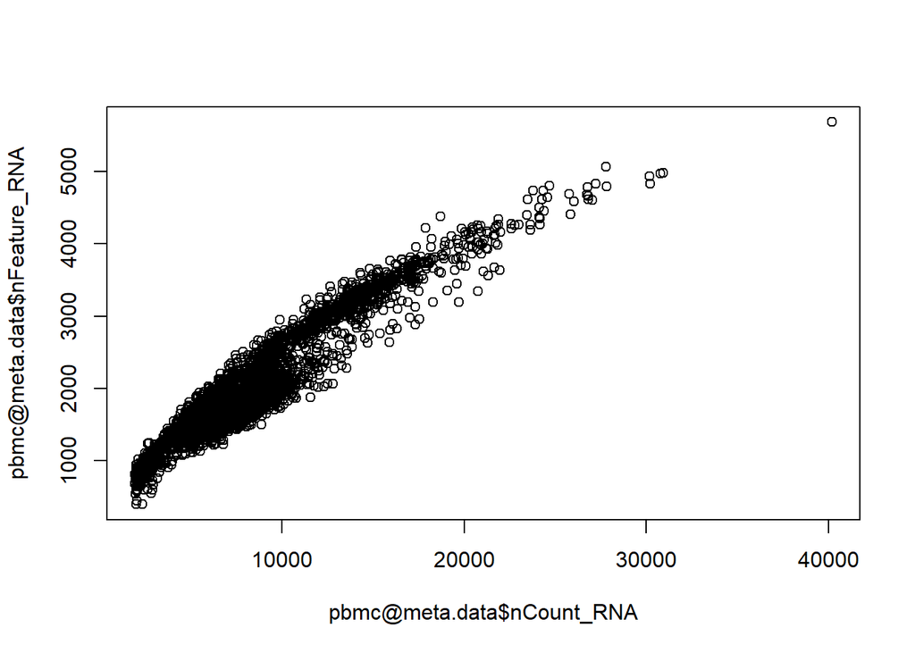

```r
plot(pbmc@meta.data$nCount_RNA, pbmc@meta.data$nFeature_RNA)
```

# Filtering the cells, counting, and visuaalizing the cells using a gg plot

```r
library(ggplot2)
# Filter cells based on nFeature_RNA and percent.mt
pbmc <- subset(pbmc, subset = nFeature_RNA > 200 & nFeature_RNA < 2500 & percent.mt < 10)
# Counting cells
n.cells <- ncol(pbmc@assays$RNA@counts)
print(paste0("Number of cells after filtering: ", n.cells))
```

```
## [1] "Number of cells after filtering: 1424"
```

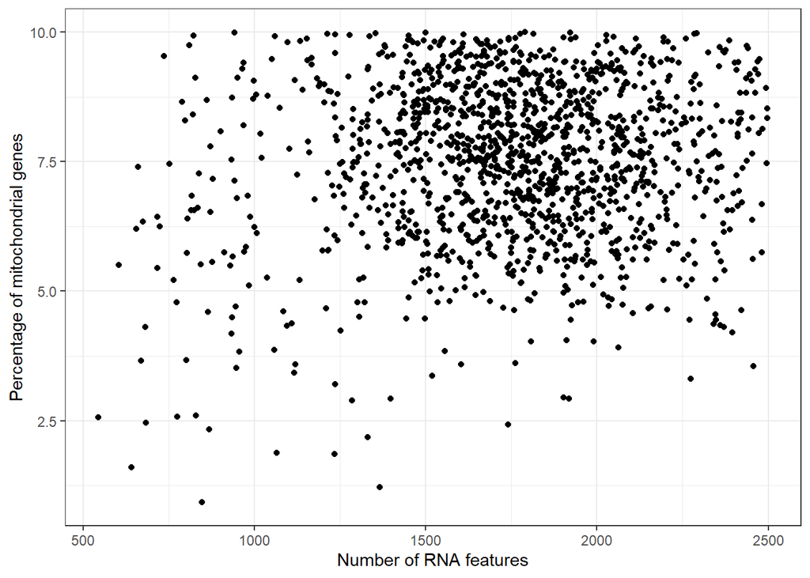

```r
# Visualize filtered cells
ggplot(pbmc@meta.data, aes(x = nFeature_RNA, y = percent.mt)) +
  geom_point() +
  labs(x = "Number of RNA features",
       y = "Percentage of mitochondrial genes") +
  theme_bw()
```

# Checking if normalization worked

Normalization involves adjusting the read counts of each gene for differences in library size, so that the overall expression of each sample is comparable. For example, RPKM normalization divides the raw read count of a gene by the length of the gene and the total number of mapped reads in the sample.

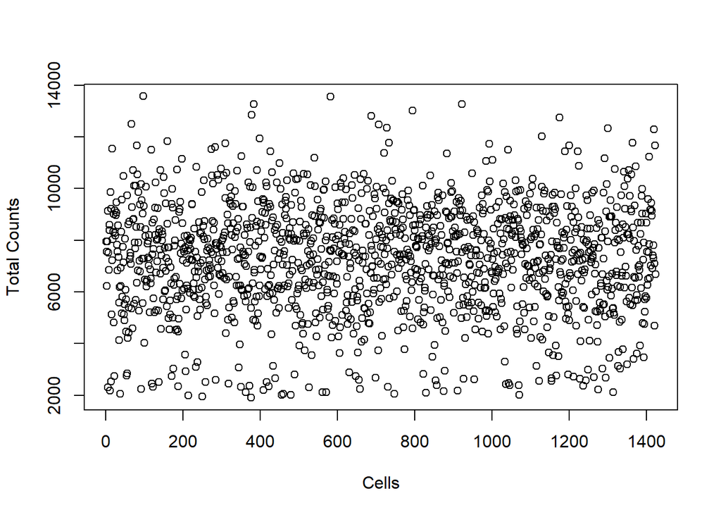

```r
plot((colSums(as.matrix(GetAssayData(pbmc, slot = "data")))),
     xlab = "Cells", ylab = "Total Counts")
```

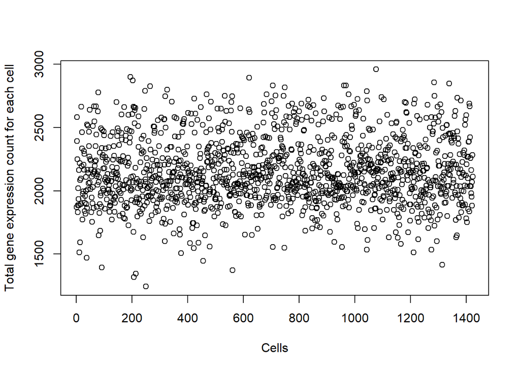

```r
pbmc <- NormalizeData(pbmc)
plot((colSums(as.matrix(GetAssayData(pbmc, slot = "data")))),
     xlab = "Cells", ylab = "Total gene expression count for each cell")
```

A brief description of this code: GetAssayData(pbmc, slot = “data”): This function call retrieves the matrix of expression data from the Seurat object pbmc. The slot = “data” argument specifies that we want the expression data from the RNA assay, which is stored in the data slot of the Seurat object.

as.matrix(): The GetAssayData() function returns a sparse matrix object of class dgCMatrix, which is a memory-efficient format for storing large matrices with many zero values. The as.matrix() function converts this sparse matrix object to a standard matrix object of class matrix, which is easier to work with for many operations.

# Identifying highly variable features

Features or genes show high cell-to-cell variation in the dataset (i.e, they are highly expressed in some cells, and lowly expressed in others). Focusing on these genes in downstream analysis helps to highlight biological signal in single-cell datasets. This finally helps to identify differentially expressed genes and making different clusters.

```r
pbmc <- FindVariableFeatures(pbmc, selection.method = "vst", nfeatures = 2000)
```

A brief description of this code: 1. selection.method = “vst” specifies that VST values will be used to calculate the variable features 2. nfeatures = 2000 specifies that the top 2000 most variable features will be selected for downstream analysis. 3. The FindVariableFeatures() function in Seurat to identify the most variable features (genes) in the pbmc object.

# Identify the 10 most highly variable genes

```r
top10 <- head(VariableFeatures(pbmc), 10)
```

# plot variable features with and without labels

```r
plot1 <- VariableFeaturePlot(pbmc)
plot2 <- LabelPoints(plot = plot1, points = top10, repel = TRUE)
```

```
## When using repel, set xnudge and ynudge to 0 for optimal results
```

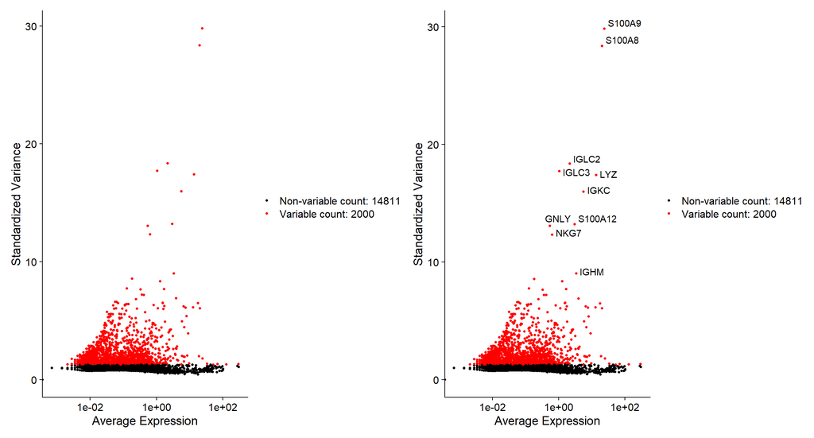

```r
plot1 + plot2
```

# Scaling the data

Scaling involves adjusting the expression levels of each gene so that they have comparable distributions across samples. For example, to perform Z-score scaling, we first calculate the mean and standard deviation of expression values for each gene across all samples. Then, we subtract the mean and divide by the standard deviation for each gene in each sample. This gives us a new set of values for each gene, where the mean is zero and the standard deviation is one across all samples. This process ensures that the distribution of expression levels for each gene is comparable across samples, making it easier to identify differentially expressed genes.

# Check if scaling worked using a heat map

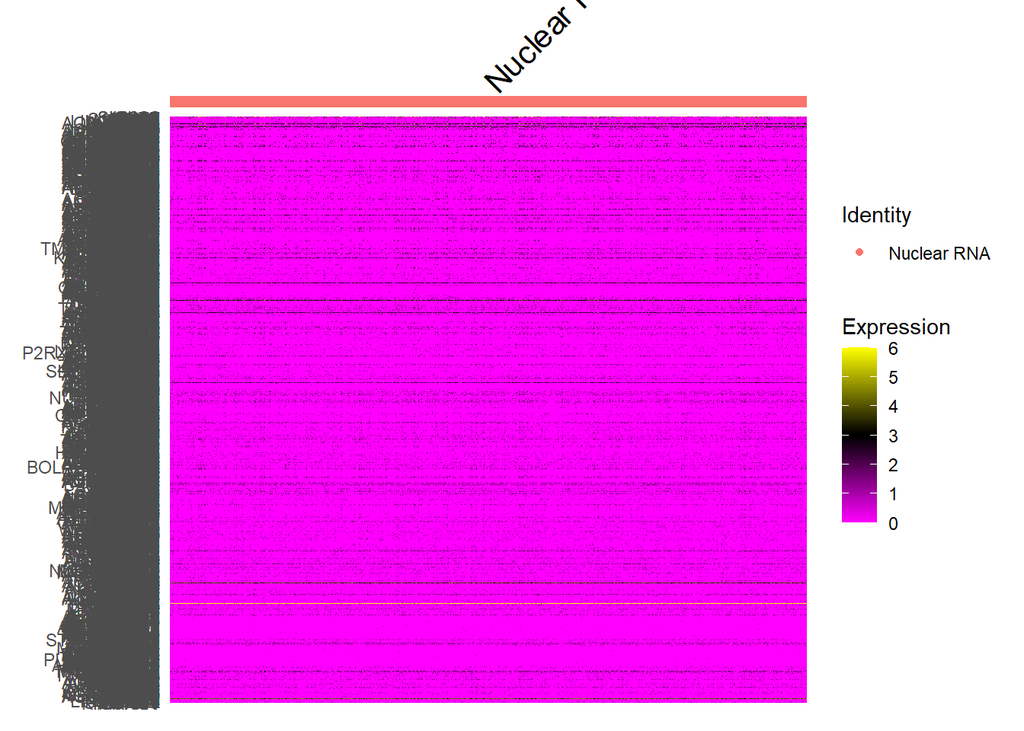

```r
DoHeatmap(pbmc, slot="data")
```

```r
all.genes <- rownames(pbmc)
pbmc <- ScaleData(pbmc, features = all.genes)
```

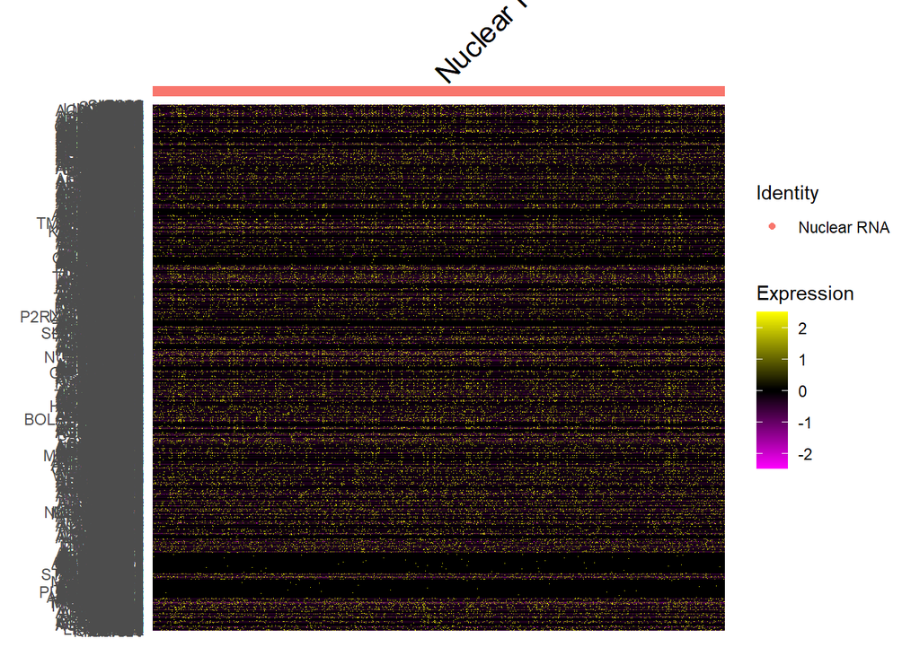

```r
DoHeatmap(pbmc, slot="scale.data")
```

In the heat map, we can see even the genes with low expression in the heatmap after scaling which suggests the scaling worked.

```r
# Get the expression values for a specific gene
gene_of_interest <- "ACTB"
expression_before_scaling <- GetAssayData(pbmc, slot = "data")[gene_of_interest, ]

# Scale the data
pbmc <- ScaleData(pbmc, features = all.genes)
```

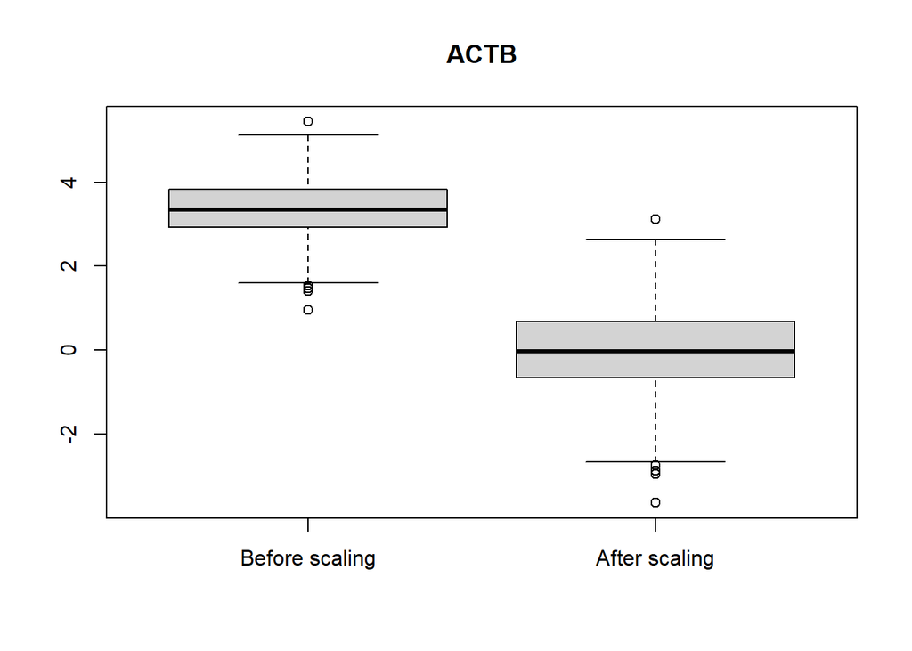

```r
# Get the expression values for the same gene after scaling
expression_after_scaling <- GetAssayData(pbmc, slot = "scale.data")[gene_of_interest, ]

# Create a boxplot to compare the expression values before and after scaling
boxplot(expression_before_scaling, expression_after_scaling,
        names = c("Before scaling", "After scaling"),
        main = gene_of_interest)
```

# We perform PCA on the scaled data:

PCA can be used to reduce the dimensionality of the data by identifying the major sources of variation and projecting the data onto a lower-dimensional space.

```r
pbmc <- RunPCA(pbmc, features = VariableFeatures(object = pbmc))
```

```
## PC_ 1
## Positive:  RPS18, RPS12, RPSA, EEF1A1, LTB, RPL21, TRAC, IL7R, TRBC2, IL32
##     NOSIP, CD7, CD69, CD2, CCR7, TRBC1, PCSK7, GZMM, MAL, SYNE2
##     AQP3, BCL2, RORA, ITM2A, PASK, NELL2, HSPB1, BIRC3, CD96, FHIT
## Negative:  MNDA, FCN1, TYROBP, S100A8, S100A9, CST3, VCAN, S100A12, CSTA, FCER1G
##     LYZ, CD14, FGL2, MS4A6A, SERPINA1, AC020656.1, MPEG1, CSF3R, CEBPD, CTSS
##     KLF4, NCF2, RGS2, LST1, GRN, CLEC7A, CD36, PSAP, CD68, TYMP
## PC_ 2
## Positive:  TRAC, IL32, IL7R, HCST, CD2, CD7, NOSIP, S100A4, VIM, ANXA1
##     TRBC1, S100A10, GZMM, RORA, AQP3, IER2, TRBC2, GAPDH, MAL, S100A6
##     PIM1, MT2A, MGAT4A, CTSW, SYNE2, S100A11, ITM2A, NEAT1, GBP2, KLRB1
## Negative:  CD79A, MS4A1, HLA-DQA1, IGHM, CD79B, HLA-DRB1, HLA-DQB1, HLA-DRA, CD74, HLA-DPA1
##     BANK1, HLA-DPB1, IGHD, CD22, LINC00926, RALGPS2, BCL11A, HLA-DQA2, TNFRSF13C, TCL1A
##     MEF2C, CD37, VPREB3, SWAP70, IGKC, HLA-DRB5, HLA-DMB, FCER2, SPIB, HLA-DMA
## PC_ 3
## Positive:  RPL21, CCR7, RPS12, EEF1A1, NOSIP, FHIT, MAL, LTB, TSHZ2, RPS18
##     IL7R, LRRN3, SLC2A3, PASK, EPHA1-AS1, TMIGD2, C1orf162, AIF1, NELL2, SLC40A1
##     ST13, SOCS3, FAM13A, PDE3B, RPSA, H1FX, SCGB3A1, BACH2, NBEAL1, IER2
## Negative:  NKG7, CST7, GZMH, GZMA, CCL5, GNLY, KLRD1, PRF1, TRGC2, GZMB
##     CCL4, FGFBP2, MATK, CTSW, KLRG1, CD8A, ADGRG1, KLRF1, CLIC3, C12orf75
##     CD160, PTGDR, EOMES, SPON2, GZMK, HOPX, LYAR, CYTOR, CMC1, GZMM
## PC_ 4
## Positive:  ITGB1, FUT7, ANXA2, S100A4, MAF, LTB, S100A10, AHNAK, PRDM1, LMNA
##     AQP3, FAM129A, KLF6, CD82, TNFRSF4, MIAT, PHACTR2, SYNE2, IL2RA, FOXP3
##     TTC39C-AS1, KLRB1, GPR183, AIM2, DUSP4, VIM, CCR4, RORA, RTKN2, S100A11
## Negative:  CD8B, CD8A, NKG7, CCR7, GZMH, GZMM, CTSW, GZMB, LRRN3, CD7
##     S100B, LINC02446, FGFBP2, GNLY, CCL4, TRGC2, CHI3L2, BACH2, AIF1, ADGRG1
##     KLRD1, MATK, FHIT, TMIGD2, SPON2, EOMES, MMP23B, TCL1A, PTGDR, CST7
## PC_ 5
## Positive:  TNFRSF13B, SSPN, IGHG1, IGHA1, AIM2, CLECL1, LINC01781, IGHA2, COCH, CPNE5
##     IGHG2, IGHG3, SCIMP, JCHAIN, BTNL9, EML6, BASP1, BLK, RASSF6, COBLL1
##     OSBPL10, TLR10, MARCKS, LINC01857, KLK1, IGHG4, NUDT4, BANK1, IGF2BP3, CD24
## Negative:  TCL1A, IGHD, PCDH9, CD72, YBX3, IL4R, AL139020.1, IGHM, PLPP5, MACROD2
##     BCL7A, FCRL5, TSPAN13, CD69, CXCR4, TCL1B, DSP, FCER2, IGLC5, CD200
##     NEIL1, MAF, FOXP3, IL32, PAX5, FOS, CCR6, LINC02397, FCRL1, PLD4
```

# Examine and visualize PCA results a few different ways.

RNA-seq datasets can be highly dimensional, with thousands of genes measured in each sample.

```r
print(pbmc[["pca"]], dims = 1:5, nfeatures = 5)
```

```
## PC_ 1
## Positive:  RPS18, RPS12, RPSA, EEF1A1, LTB
## Negative:  MNDA, FCN1, TYROBP, S100A8, S100A9
## PC_ 2
## Positive:  TRAC, IL32, IL7R, HCST, CD2
## Negative:  CD79A, MS4A1, HLA-DQA1, IGHM, CD79B
## PC_ 3
## Positive:  RPL21, CCR7, RPS12, EEF1A1, NOSIP
## Negative:  NKG7, CST7, GZMH, GZMA, CCL5
## PC_ 4
## Positive:  ITGB1, FUT7, ANXA2, S100A4, MAF
## Negative:  CD8B, CD8A, NKG7, CCR7, GZMH
## PC_ 5
## Positive:  TNFRSF13B, SSPN, IGHG1, IGHA1, AIM2
## Negative:  TCL1A, IGHD, PCDH9, CD72, YBX3
```

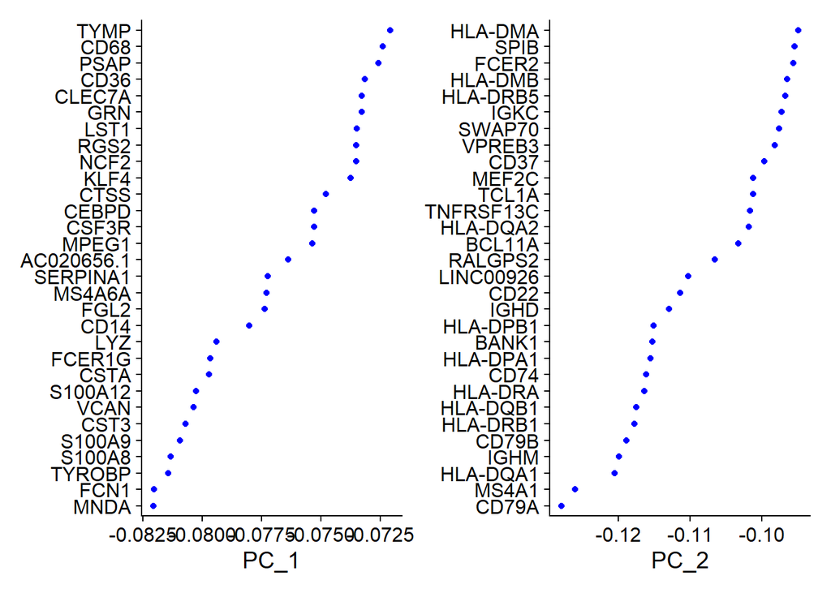

```r
VizDimLoadings(pbmc, dims = 1:2, reduction = "pca")
```

```r
saveRDS(pbmc, "pbmc_1.rds")
```

```r
pbmc <- RunPCA(pbmc, features = VariableFeatures(object = pbmc))
```

```
## PC_ 1
## Positive:  RPS18, RPS12, RPSA, EEF1A1, LTB, RPL21, TRAC, IL7R, TRBC2, IL32
##     NOSIP, CD7, CD69, CD2, CCR7, TRBC1, PCSK7, GZMM, MAL, SYNE2
##     AQP3, BCL2, RORA, ITM2A, PASK, NELL2, HSPB1, BIRC3, CD96, FHIT
## Negative:  MNDA, FCN1, TYROBP, S100A8, S100A9, CST3, VCAN, S100A12, CSTA, FCER1G
##     LYZ, CD14, FGL2, MS4A6A, SERPINA1, AC020656.1, MPEG1, CSF3R, CEBPD, CTSS
##     KLF4, NCF2, RGS2, LST1, GRN, CLEC7A, CD36, PSAP, CD68, TYMP
## PC_ 2
## Positive:  TRAC, IL32, IL7R, HCST, CD2, CD7, NOSIP, S100A4, VIM, ANXA1
##     TRBC1, S100A10, GZMM, RORA, AQP3, IER2, TRBC2, GAPDH, MAL, S100A6
##     PIM1, MT2A, MGAT4A, CTSW, SYNE2, S100A11, ITM2A, NEAT1, GBP2, KLRB1
## Negative:  CD79A, MS4A1, HLA-DQA1, IGHM, CD79B, HLA-DRB1, HLA-DQB1, HLA-DRA, CD74, HLA-DPA1
##     BANK1, HLA-DPB1, IGHD, CD22, LINC00926, RALGPS2, BCL11A, HLA-DQA2, TNFRSF13C, TCL1A
##     MEF2C, CD37, VPREB3, SWAP70, IGKC, HLA-DRB5, HLA-DMB, FCER2, SPIB, HLA-DMA
## PC_ 3
## Positive:  RPL21, CCR7, RPS12, EEF1A1, NOSIP, FHIT, MAL, LTB, TSHZ2, RPS18
##     IL7R, LRRN3, SLC2A3, PASK, EPHA1-AS1, TMIGD2, C1orf162, AIF1, NELL2, SLC40A1
##     ST13, SOCS3, FAM13A, PDE3B, RPSA, H1FX, SCGB3A1, BACH2, NBEAL1, IER2
## Negative:  NKG7, CST7, GZMH, GZMA, CCL5, GNLY, KLRD1, PRF1, TRGC2, GZMB
##     CCL4, FGFBP2, MATK, CTSW, KLRG1, CD8A, ADGRG1, KLRF1, CLIC3, C12orf75
##     CD160, PTGDR, EOMES, SPON2, GZMK, HOPX, LYAR, CYTOR, CMC1, GZMM
## PC_ 4
## Positive:  ITGB1, FUT7, ANXA2, S100A4, MAF, LTB, S100A10, AHNAK, PRDM1, LMNA
##     AQP3, FAM129A, KLF6, CD82, TNFRSF4, MIAT, PHACTR2, SYNE2, IL2RA, FOXP3
##     TTC39C-AS1, KLRB1, GPR183, AIM2, DUSP4, VIM, CCR4, RORA, RTKN2, S100A11
## Negative:  CD8B, CD8A, NKG7, CCR7, GZMH, GZMM, CTSW, GZMB, LRRN3, CD7
##     S100B, LINC02446, FGFBP2, GNLY, CCL4, TRGC2, CHI3L2, BACH2, AIF1, ADGRG1
##     KLRD1, MATK, FHIT, TMIGD2, SPON2, EOMES, MMP23B, TCL1A, PTGDR, CST7
## PC_ 5
## Positive:  TNFRSF13B, SSPN, IGHG1, IGHA1, AIM2, CLECL1, LINC01781, IGHA2, COCH, CPNE5
##     IGHG2, IGHG3, SCIMP, JCHAIN, BTNL9, EML6, BASP1, BLK, RASSF6, COBLL1
##     OSBPL10, TLR10, MARCKS, LINC01857, KLK1, IGHG4, NUDT4, BANK1, IGF2BP3, CD24
## Negative:  TCL1A, IGHD, PCDH9, CD72, YBX3, IL4R, AL139020.1, IGHM, PLPP5, MACROD2
##     BCL7A, FCRL5, TSPAN13, CD69, CXCR4, TCL1B, DSP, FCER2, IGLC5, CD200
##     NEIL1, MAF, FOXP3, IL32, PAX5, FOS, CCR6, LINC02397, FCRL1, PLD4
```

```r
print(pbmc[["pca"]], dims = 1:5, nfeatures = 5)
```

```
## PC_ 1
## Positive:  RPS18, RPS12, RPSA, EEF1A1, LTB
## Negative:  MNDA, FCN1, TYROBP, S100A8, S100A9
## PC_ 2
## Positive:  TRAC, IL32, IL7R, HCST, CD2
## Negative:  CD79A, MS4A1, HLA-DQA1, IGHM, CD79B
## PC_ 3
## Positive:  RPL21, CCR7, RPS12, EEF1A1, NOSIP
## Negative:  NKG7, CST7, GZMH, GZMA, CCL5
## PC_ 4
## Positive:  ITGB1, FUT7, ANXA2, S100A4, MAF
## Negative:  CD8B, CD8A, NKG7, CCR7, GZMH
## PC_ 5
## Positive:  TNFRSF13B, SSPN, IGHG1, IGHA1, AIM2
## Negative:  TCL1A, IGHD, PCDH9, CD72, YBX3
```

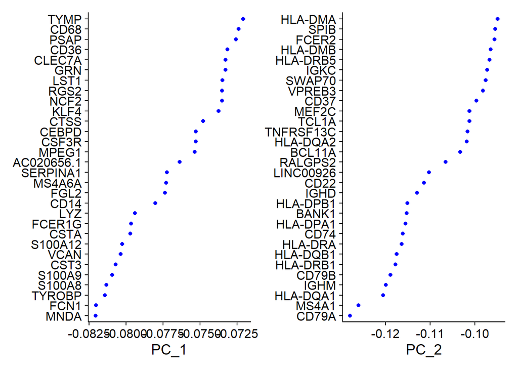

```r
VizDimLoadings(pbmc, dims = 1:2, reduction = "pca")
```

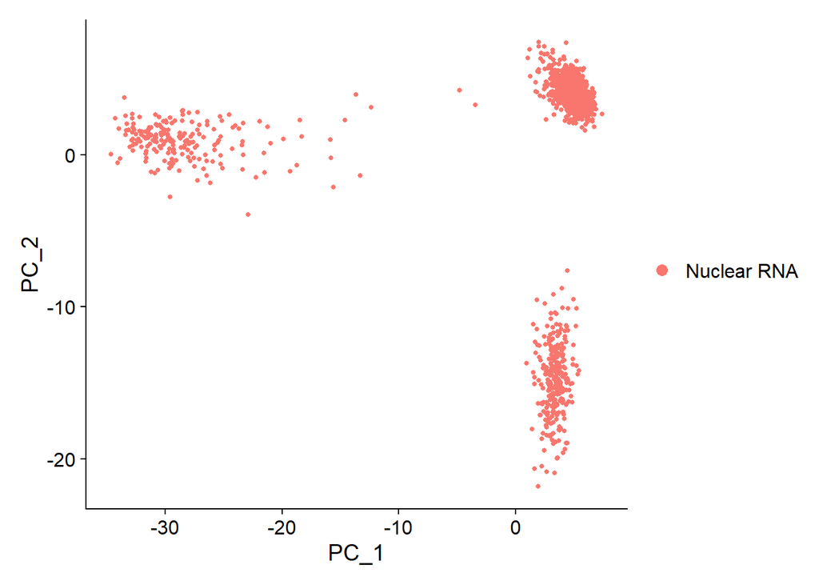

```r
DimPlot(pbmc, reduction = "pca")
```

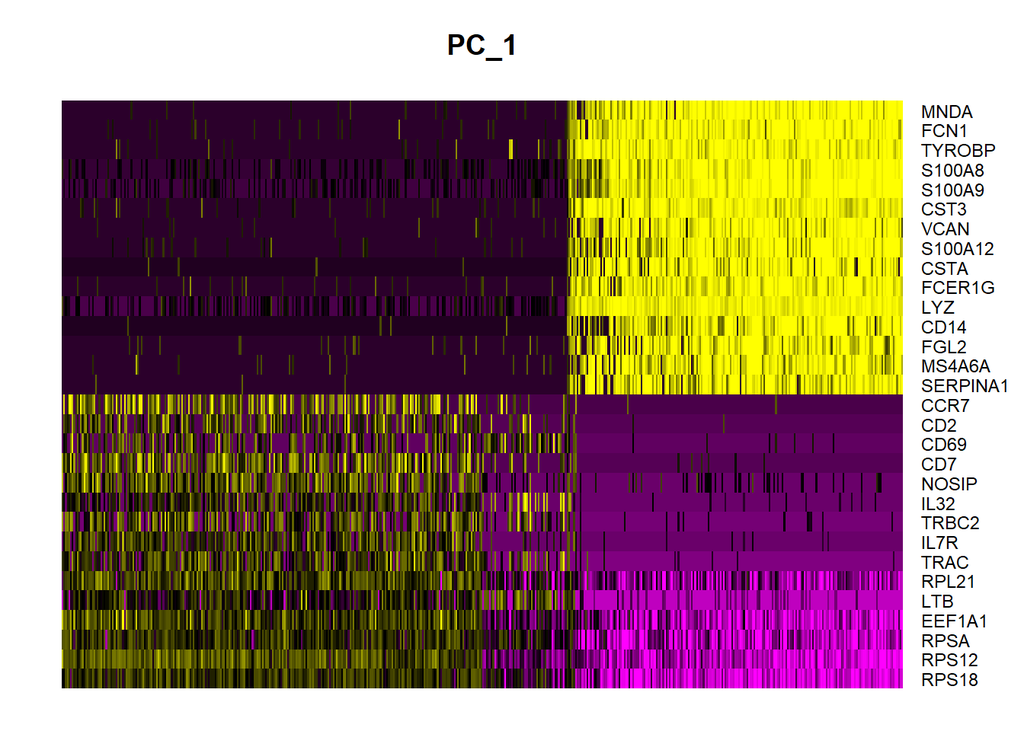

```r
DimHeatmap(pbmc, dims = 1, cells = 500, balanced = TRUE)
```

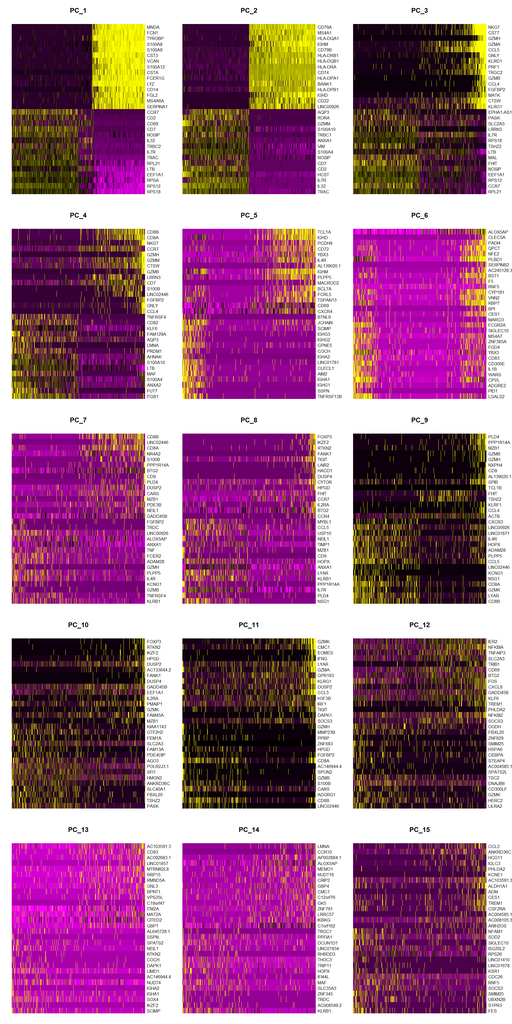

```r
DimHeatmap(pbmc, dims = 1:15, cells = 500, balanced = TRUE)
```

```r
# NOTE: This process can take a long time for big datasets, comment out for expediency. More
# approximate techniques such as those implemented in ElbowPlot() can be used to reduce
# computation time
pbmc <- JackStraw(pbmc, num.replicate = 100)
pbmc <- ScoreJackStraw(pbmc, dims = 1:20)
```

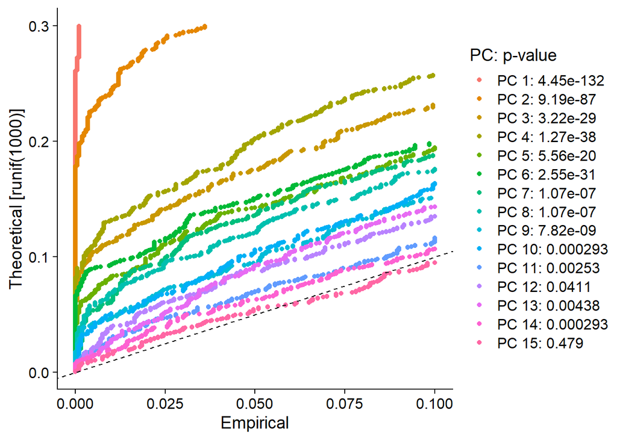

```r
JackStrawPlot(pbmc, dims = 1:15)
```

# This helps to select dimensions for clustering analysis based on the variance of different PCAs.

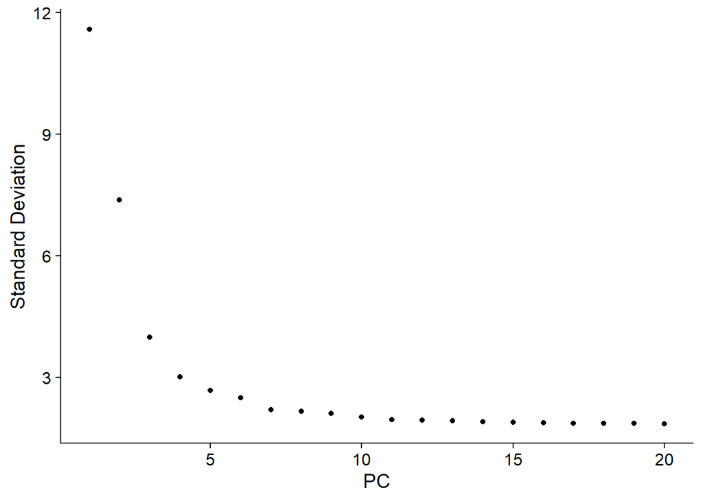

```r
ElbowPlot(pbmc)
```

# Clustering

```r
pbmc <- FindNeighbors(pbmc, dims = 1:6)
pbmc <- FindClusters(pbmc, resolution = 0.7)
```

```
## Modularity Optimizer version 1.3.0 by Ludo Waltman and Nees Jan van Eck
##
## Number of nodes: 1424
## Number of edges: 44628
##
## Running Louvain algorithm...
## Maximum modularity in 10 random starts: 0.8454
## Number of communities: 9
## Elapsed time: 0 seconds
```

# Using non-linear dimensional reduction techniques, UMAP, to visualize and explore these cluster datasets.

Uniform Manifold Approximation and Projection (UMAP) works by modeling the data as a high-dimensional manifold and finding a low-dimensional embedding that preserves the manifold structure. Here, UMAP is used to visualize clusters of cells with similar expression profiles, or to identify genes that drive differences between cell types.

```r
pbmc <- RunUMAP(pbmc, dims = 1:6 )
```

```
## 17:51:41 Found 2 connected components, falling back to 'spca' initialization with init_sdev = 1
## 17:51:41 PCA: 2 components explained 83.11% variance
## 17:51:41 Scaling init to sdev = 1
```

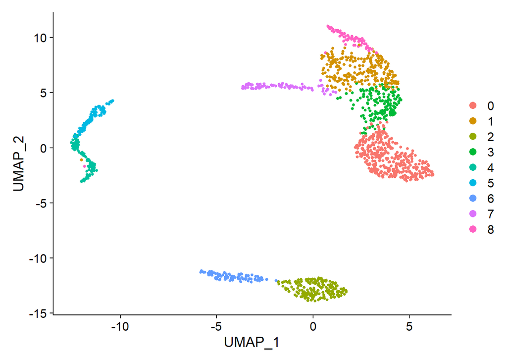

```r
DimPlot(pbmc, reduction = "umap")
```

```r
pbmc@meta.data[1:5,]
```

```
##                     orig.ident nCount_RNA nFeature_RNA percent.mt percent.CD14
## AAAGAACGTTTGTTGG-1 Nuclear RNA       7955         1585   8.937775    0.0000000
## AAAGGATTCTGCGGGT-1 Nuclear RNA       6230         1861   7.993579    0.0000000
## AAAGGGCTCTTCCACG-1 Nuclear RNA       7564         2114   9.875727    0.1718667
## AAAGGTAGTCTACACA-1 Nuclear RNA       7955         1912   4.047769    0.0000000
## AAAGGTAGTTAAGGAT-1 Nuclear RNA       9127         1654   5.730251    0.0000000
##                    percent.CD79A percent.PF4 percent.MT RNA_snn_res.0.7
## AAAGAACGTTTGTTGG-1             0  0.02514142   9.277184               0
## AAAGGATTCTGCGGGT-1             0  0.01605136   8.507223               7
## AAAGGGCTCTTCCACG-1             0  0.02644104  10.378107               4
## AAAGGTAGTCTACACA-1             0  0.03771213   4.462602               1
## AAAGGTAGTTAAGGAT-1             0  0.03286951   5.949381               0
##                    seurat_clusters
## AAAGAACGTTTGTTGG-1               0
## AAAGGATTCTGCGGGT-1               7
## AAAGGGCTCTTCCACG-1               4
## AAAGGTAGTCTACACA-1               1
## AAAGGTAGTTAAGGAT-1               0
```

# find all markers of cluster 2

```r
cluster2.markers <- FindMarkers(pbmc, ident.1 = 2, min.pct = 0.25)
```

[output not shown]

```r
head(cluster2.markers, n = 5)
```

```
##               p_val avg_log2FC pct.1 pct.2     p_val_adj
## TCL1A 2.995946e-266   3.621419 0.921 0.009 5.036485e-262
## IGHD  9.151777e-237   3.377185 0.960 0.038 1.538505e-232
## IGHM  5.365378e-185   4.194110 0.989 0.103 9.019736e-181
## CD79A 4.371483e-177   3.003211 1.000 0.107 7.348901e-173
## MS4A1 4.665827e-164   2.691832 0.972 0.106 7.843721e-160
```